# Stats 250: Lab 1 Assignment

Elan Grossman

September 14, 2023

### Instructions

Complete the lab exercises and Dive Deeper questions below. Lab exercises will be graded out of 2 points each and the Dive Deeper questions will be graded out of 3 points each - all of them will be graded for *correctness*. Upon completion, follow the submission instructions at the bottom of this document. We strongly encourage you to work on this assignment with a partner.

### Background

This data set contains information on *all* 801 Pokemon from the first Seven Generations of Pokemon. The variables in the data set include:

1. `primary_type`: primary type of the Pokemon (grass, fire, water, etc.)
2. `secondary_type`: secondary type of the Pokemon (poison, flying, none, etc.)
3. `legendary_status`: denotes if the Pokemon is of legendary status
4. `attack`: base attack of the Pokemon (in points)
5. `defense`: base defense of the Pokemon (in points)
6. `hp`: base HP (hit points) of the Pokemon (in points)
7. `speed`: base speed of the Pokemon (in points)
8. `special_attack`: base special attack of the Pokemon (in points)
9. `special_defense`: base special defense of the Pokemon (in points)
10. `capture_rate`: capture rate of the Pokemon (in points)
11. `base_total`: total base score of the Pokemon (in points)
12. `weight_kg`: weight of the Pokemon (in kg)*
13. `generation`: classifies the generation in which the Pokemon was introduced

*Note: some of the Pokemon do not have a weight specified and are listed as NA

[Source](https://www.kaggle.com/datasets/rounakbanik/pokemon)

Use the following code chunk to read in the data set.

```r
pokemon <- read.csv("pokemon.csv", row.names = 1)
```

And be sure to load in the required packages!

```r
library(ggplot2)
```

### Lab Exercises

After reading the background above, complete the following lab exercises. Remember, these exercises are worth 2 points each and are graded for *correctness*.

> **1.** Select a *quantitative* variable from the data set and create a histogram. Be sure to appropriately update the plot title and axis labels.

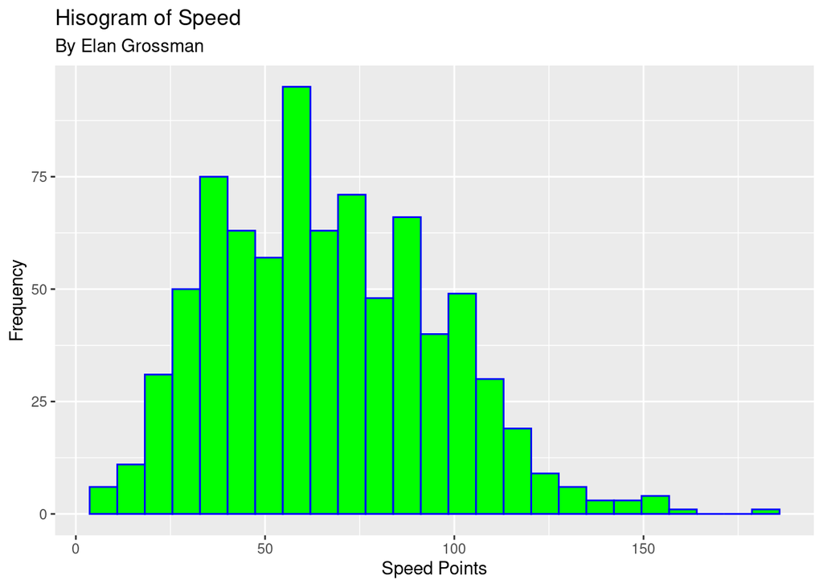

```r
ggplot(data = pokemon, aes(x = speed)) +
  geom_histogram(bins = 25,
                 color = "blue",
                 fill = "green") +
  labs(title = "Hisogram of Speed",
       subtitle = "By Elan Grossman",
       x = "Speed Points",
       y = "Frequency")
```

> **2.** Using the same variable from Exercise 1, calculate at least three useful numerical summaries that would help provide a thorough description of the variable’s distribution.

```r
mean(pokemon$speed)
```

```
## [1] 66.33458
```

```r
max(pokemon$speed)
```

```
## [1] 180
```

```r
min(pokemon$speed)
```

```
## [1] 5
```

```r
median(pokemon$speed)
```

```
## [1] 65
```

```r
sd(pokemon$speed)
```

```
## [1] 28.90766
```

> **3.** Using the histogram from Exercise 1 and the exact numerical values calculated in Exercise 2, thoroughly describe the distribution of your quantitative variable. Your response should be 2-3 sentences in length and describe at minimum the distribution’s shape, center, and spread.

> **4.** Select a *different* quantitative variable from the data set and create a histogram. Be sure to appropriately update the plot title and axis labels.

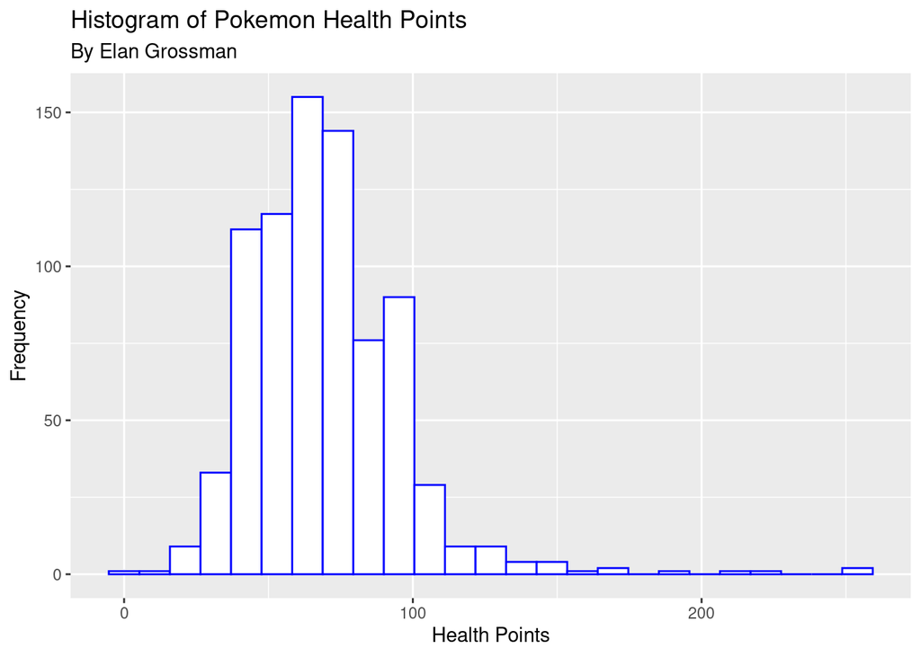

```r
HealthPoints <- pokemon$hp
ggplot(data = pokemon, aes(x = HealthPoints)) +
  geom_histogram(bins = 25,
                 color = "blue",
                 fill = "white") +
  labs(title = "Histogram of Pokemon Health Points",
       subtitle = "By Elan Grossman",
       x = "Health Points",
       y = "Frequency")
```

> **5.** Using the same variable from Exercise 4, calculate at least three useful numerical summaries that would help provide a thorough description of the variable’s distribution.

```r
mean(HealthPoints)
```

```
## [1] 68.9588
```

```r
max(HealthPoints)
```

```
## [1] 255
```

```r
min(HealthPoints)
```

```
## [1] 1
```

```r
median(HealthPoints)
```

```
## [1] 65
```

```r
sd(HealthPoints)
```

```
## [1] 26.57601
```

> **6.** Using the histogram from Exercise 4 and the exact numerical values calculated in Exercise 5, thoroughly describe the distribution of your quantitative variable. Your response should be 2-3 sentences in length and describe at minimum the distribution’s shape, center, and spread.

*Answer:* The distribution of Health Points (HP) for all Pokemon is roughly symmetrical with a few outliers making the skew right The mean is greater than the median since 68.96 is greater than 65 points and the range is large from a min of 1 to a max of 255.

> **7.** Select a *categorical* variable from the data set and create a bar chart in the first code chunk. Be sure to appropriately update the plot title and axis labels. In the second code chunk, create a frequency table for your selected categorical variable.

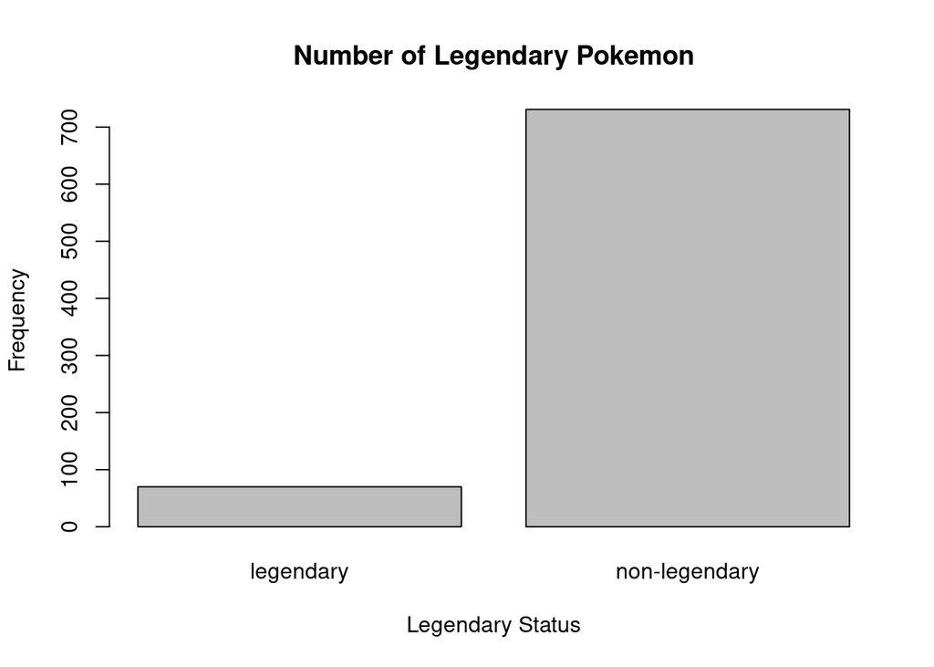

```r
barplot(table(pokemon$legendary_status),
        ylab = "Frequency",
        xlab = "Legendary Status",
        main ="Number of Legendary Pokemon")
```

```r
table(pokemon$legendary_status)
```

```
##
##     legendary non-legendary
##            70           731
```

### Dive Deeper Questions

After completing the lab exercises above, complete the following Dive Deeper questions. Remember, these questions are worth 3 points each and are graded for correctness.

> **1.** The last variable in the data set is `generation`. This variable classifies the generation in which the Pokemon was introduced. Would this variable be considered quantitative or categorical? Explain your answer in 2-3 sentences.

```r
#pokemon
```

Wikipedia

*Answer:* I think pokemon generation would be categorical because it classifies the pokemon into the generations they were introduced. There are only 7 different generations the pokemon can be classified into and none seem to have any superiority over the others making it categorical nominal.

> **2.** Propose a question that could be answered using the Pokemon data set. Your question should involve *two* variables. After stating your question, identify which variable is acting as the response variable and which variable is acting as the explanatory variable.

*Answer:* Does the pokemon generation affect the number of health points a pokemon has? The explanatory variable would be the generation and the response variable would be the number of health points. Another question I could ask could be Does the primary_type of each pokemon affect the amount of attack points they have? primary_type would be explanatory and attack points would be response.

### Submission Instructions

Once you have finished, follow the instructions below to submit your work.

1. At the top of the document, update the `author` field. Do not change anything else at the top of the document.
2. Click the Knit button to create an HTML file of your work.
3. In the Files pane (bottom right window), check the box next to `lab01_assignment.html`.
4. In the Files pane, click on the gear icon (More) and select “Export…”
5. Do not change the file name (`lab01_assignment.html`). Click Download and save the file to your computer.
6. On the Stats 250 Canvas site, navigate to the Lab 1 assignment.
7. Upload your saved `lab01_assignment.html` file.
8. Click “Submit Assignment”. Congratulations, you are done with Lab 1!